# Clean 4 - log ratios and pairwise comparisons

TG

2025-01-11

load packages

```r
library(DarkDiv)
library(tidyverse)
library(vegan)
library(plotrix)
library(sjPlot)
library(sjmisc)
library(gridExtra)
library(lme4)
library(lmerTest)
library(MuMIn)
library(glmmTMB)
library(DHARMa)
library(ggeffects)
library(SingleCaseES)
library(metafor)
library(patchwork)
library(knitr)


select <- dplyr::select

dir<-"G:\\My Drive\\PHD\\chapter 3 MPA dd\\Meddata-DD\\final plots and models\\log ratios and pairwise"
```

load data bases

```r
#load("G:\\My Drive\\PHD\\chapter 3 MPA dd\\Meddata-DD\\clean output data\\Clean_MeData_dd.Rdata")

load("G:\\My Drive\\PHD\\chapter 3 MPA dd\\Meddata-DD\\clean output data\\Clean_MeData_dd_lis.Rdata")

load("G:\\My Drive\\PHD\\chapter 3 MPA dd\\Meddata-DD\\clean output data\\pairs.Rdata")
```

# In this script:

1. log-ratio analyses for pairs of MPAs and control sites
2. pair-wise analyses of the 3 case sudies
3. completeness log ratio

# Input files:

loaded from the `clean output data` folder

- `Clean_medata_dd_lis.Rdata` - dark diversity calculation for MeData
- `pairs.Rdata` - list of pairs of MPA and control site

# Outputs files:

all plots saved in `log ratios and pairwise` folder

- `fig_4_left` - plot of log ratio + metafor models (Fig 4)
- `fig_4_right` - plot of pairwise comparison of the 3 study cases (Fig 4)
- `Completeness_effect_size` - plot of log ratio + metafor models for completeness (Appendix 6)

# Log ratio models

## Data prepartions

```r
# unite the dark diversity data with the pairs classification

log_data<-left_join(dd_data,pairs)
# remove the data that dont belong to a MPA-control pair

log_data<-log_data %>% drop_na(pair)

# fix capital latter in pairs

log_data$pair<-str_to_title(log_data$pair)

# convert pair to factor

log_data$pair<-as.factor(log_data$pair)

# remove unnecessary columns

log_data<-log_data %>% select(pair,protection,enforcement,dark,observed_richness,total)


# calculate completeness


log_data<-log_data %>% mutate("completeness" = log(observed_richness/dark))

# convert to long format

log_data<-gather(log_data,"index","richness",4:7)

# create list of all fully protected MPAs

fully_protected_pairs<- log_data %>% filter(enforcement>2) %>% distinct(pair)

# Change protected/no protected to MPA vs Control

log_data$protection<-ifelse(log_data$protection=="Protected","MPA","Control")
```

use the `batch_calc_ES` function to calculate the log-ratio for the diversity component: dark diversity, observed richness and site species pool for the sites log plot

## Log-ratio - dark diversity

```r
# keep the dark diversity index only

d_ratio<-log_data %>% filter(index == "dark")


# apply the `batch_calc_ES` to recive log-ratios

d_ratio = batch_calc_ES(dat = d_ratio, grouping =  pair, condition = protection, outcome = richness,scale = "count", ES = "LRRi",baseline_phase  = "Control")

# arrange the order of pairs by the effect size

d_ratio<-d_ratio%>% mutate(pair = fct_reorder(pair,Est))

d_ratio$Index = "Dark diversity"
```

## Log-ratio - observed richness

```r
# keep only observed richness

o_ratio<-log_data %>% filter(index == "observed_richness")

# apply the `batch_calc_ES` to get log-ratios

o_ratio = batch_calc_ES(dat = o_ratio, grouping = pair, condition = protection, outcome = richness,scale = "count", ES = "LRRi",baseline_phase = "Control")

o_ratio$Index<-"Observed richness"
```

## Log-ratio - site species pool

```r
# keep only species pool (total)

t_ratio<-log_data %>% filter(index == "total")

# apply the `batch_calc_ES` to get log-ratios

t_ratio = batch_calc_ES(dat = t_ratio, grouping = pair, condition = protection, outcome = richness,scale = "count", ES = "LRRi",baseline_phase = "Control")

t_ratio$Index<-"Species pool"
```

### Log-ratio plot

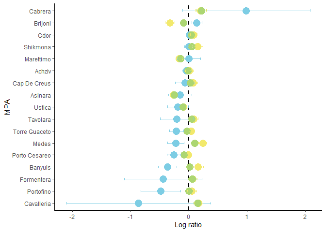

```r
plot_log_ratio<- ggplot(data = d_ratio,aes(x=Est,y=pair,color = Index))+
  geom_vline(xintercept = 0,linetype = "dashed",size = 1)+
  geom_point(size = 5)+
  geom_point(data = o_ratio,aes(x=Est,y= pair,color=Index),size = 5)+
  geom_point(data = t_ratio,aes(x=Est,y= pair,color=Index),size =5)+
  theme_classic()+
  ylab("MPA")+
  xlab("Log ratio")+
  geom_errorbar(data = d_ratio,aes(xmin= Est-SE, xmax=Est+SE), width=.2)+
  geom_errorbar(data = o_ratio ,aes(xmin= Est-SE, xmax=Est+SE), width=.2)+
  geom_errorbar(data = t_ratio ,aes(xmin= Est-SE, xmax=Est+SE), width=.2)+
  scale_color_manual(values=c('#7DCDE4',"#F2E96C","#ACD672"))+
  theme_classic()+
  theme(legend.position = 'none')
plot_log_ratio
```

# Metafor summary

Add meta-analyses summery using `metafor` package

First set the data for the metafor analyses for each diversity component

## Prepare data for all MPA

```r
# dark diversity

metafor_dark<-log_data %>%
  filter(index =="dark") %>%
  group_by(pair,protection) %>%
  summarise("mean"= mean(richness),
            "sd"=sd(richness),
            "n" = n()) %>%
  pivot_wider(names_from=protection,
              values_from=c(mean,
                            sd,
                            n))
# Observed richness

metafor_obs<-log_data %>%
  filter(index =="observed_richness") %>%
  group_by(pair,protection) %>%
  summarise("mean"= mean(richness),
            "sd"=sd(richness),
            "n" = n()) %>%
  pivot_wider(names_from=protection,
              values_from=c(mean,
                            sd,
                            n))
# Species pool

metafor_total<-log_data %>%
  filter(index =="total") %>%
  group_by(pair,protection) %>%
  summarise("mean"= mean(richness),
            "sd"=sd(richness),
            "n" = n()) %>%
  pivot_wider(names_from=protection,
              values_from=c(mean,
                            sd,
                            n))
```

## Prepare data for fully protected MPA

I repeat the analysis to acount for sites like Asinara that have both enforcment = 2 and enforcment = 3

```r
# dark diversity

metafor_dark_pro<-log_data %>%
  filter(index =="dark") %>%
  filter(!(pair == "Asinara" & enforcement == 2)) %>%
  filter(pair %in% fully_protected_pairs$pair) %>%
  group_by(pair,protection) %>%
  summarise("mean"= mean(richness),
            "sd"=sd(richness),
            "n" = n()) %>%
  pivot_wider(names_from=protection,
              values_from=c(mean,
                            sd,
                            n))
# Observed richness

metafor_obs_pro<-log_data %>%
  filter(index =="observed_richness") %>%
  filter(!(pair == "Asinara" & enforcement == 2)) %>%
  filter(pair %in% fully_protected_pairs$pair) %>%
  group_by(pair,protection) %>%
  summarise("mean"= mean(richness),
            "sd"=sd(richness),
            "n" = n()) %>%
  pivot_wider(names_from=protection,
              values_from=c(mean,
                            sd,
                            n))
# Species pool

metafor_total_pro<-log_data %>%
  filter(index =="total") %>%
  filter(!(pair == "Asinara" & enforcement == 2)) %>%
  filter(pair %in% fully_protected_pairs$pair) %>%
  group_by(pair,protection) %>%
  summarise("mean"= mean(richness),
            "sd"=sd(richness),
            "n" = n()) %>%
  pivot_wider(names_from=protection,
              values_from=c(mean,
                            sd,
                            n))
```

## Metafor - dark diversity - all MPA

Calculate the effect sizes using the `escalc` function

```r
effect_sizes_dark <- escalc(     # Function for calculating effect sizes
    "ROM",                       # Specify the effect size we want to calculate
    m1i = mean_MPA,              # MPA mean richness
    n1i = n_MPA,                 # MPA sample size
    sd1i = sd_MPA,               # MPA SD
    m2i = mean_Control,          # control mean richness
    n2i = n_Control,             # control sample size
    sd2i = sd_Control,           # control site SD
    data = metafor_dark)         # data for  meta-analysis

# calculate the SE from the variance

effect_sizes_dark$se = sqrt(effect_sizes_dark$vi)

# calculate the overall effect

dark_model <- rma(yi,                       # effect size from each row in database
                  vi,                       # measure of variance from each row in database
                  method = "REML",          # Specifies fixed effects model
                  slab = pair,              # prepares  labels for the forest plot
                  data = effect_sizes_dark) # dataframe used for model

dark_model
```

```
##
## Random-Effects Model (k = 17; tau^2 estimator: REML)
##
## tau^2 (estimated amount of total heterogeneity): 0.0091 (SE = 0.0091)
## tau (square root of estimated tau^2 value):      0.0955
## I^2 (total heterogeneity / total variability):   36.68%
## H^2 (total variability / sampling variability):  1.58
##
## Test for Heterogeneity:
## Q(df = 16) = 22.4028, p-val = 0.1307
##
## Model Results:
##
## estimate      se     zval    pval    ci.lb    ci.ub
##  -0.0897  0.0430  -2.0877  0.0368  -0.1740  -0.0055  *
##
## ---
## Signif. codes:  0 '***' 0.001 '**' 0.01 '*' 0.05 '.' 0.1 ' ' 1
```

## Metafor - dark diversity - fully protected

calculate the overall effect only for fully protected MPAs

```r
effect_sizes_dark_pro <- escalc( # Function for calculating effect sizes
    "ROM",                       # Specify the effect size we want to calculate
    m1i = mean_MPA,              # MPA mean richness
    n1i = n_MPA,                 # MPA sample size
    sd1i = sd_MPA,               # MPA SD
    m2i = mean_Control,          # control mean richness
    n2i = n_Control,             # control sample size
    sd2i = sd_Control,           # control site SD
    data = metafor_dark_pro)     # data for  meta-analysis

# calculate the SE from the variance

effect_sizes_dark_pro$se = sqrt(effect_sizes_dark_pro$vi)

pro_dark_model <- rma(yi,
                      vi,
                      method = "REML",
                      slab = pair,
                      data = effect_sizes_dark_pro)


pro_dark_model
```

```
##
## Random-Effects Model (k = 9; tau^2 estimator: REML)
##
## tau^2 (estimated amount of total heterogeneity): 0.0211 (SE = 0.0226)
## tau (square root of estimated tau^2 value):      0.1451
## I^2 (total heterogeneity / total variability):   50.73%
## H^2 (total variability / sampling variability):  2.03
##
## Test for Heterogeneity:
## Q(df = 8) = 14.6202, p-val = 0.0670
##
## Model Results:
##
## estimate      se     zval    pval    ci.lb    ci.ub
##  -0.1485  0.0746  -1.9904  0.0465  -0.2946  -0.0023  *
##
## ---
## Signif. codes:  0 '***' 0.001 '**' 0.01 '*' 0.05 '.' 0.1 ' ' 1
```

Insert to data frame

```r
# summary of all MPAs

d_summary<-d_ratio[1,c(1,7)] # create template with 1 row

d_summary$pair <- "All MPAs" # change "pair" name

d_summary$SE<-dark_model$se # get SE from the model

d_summary$Est<-dark_model$b[[1]] # get the estimate from the model

d_summary$p_val<-dark_model[["pval"]] # get the p-value from the model


# summary of fully protected MPAs

d_summary_pro<-d_ratio[1,c(1,7)]

d_summary_pro$pair <- "Fully protected MPAs"

d_summary_pro$SE<-pro_dark_model$se

d_summary_pro$Est<-pro_dark_model$b[[1]]

d_summary_pro$p_val<-pro_dark_model[["pval"]]

# join

d_summary<-rbind(d_summary,d_summary_pro)

rm(d_summary_pro)
```

## Metafor - Observed richness - all MPA

```r
# calculate effect size

effect_sizes_obs <- escalc(
    "ROM",
    m1i = mean_MPA,
    n1i = n_MPA,
    sd1i = sd_MPA,
    m2i = mean_Control,
    n2i = n_Control,
    sd2i = sd_Control,
    data = metafor_obs)

#calculate overall effect

obs_model<- rma(yi,
                vi,
                method = "REML",
                slab = pair,
                data = effect_sizes_obs)

obs_model
```

```
##
## Random-Effects Model (k = 17; tau^2 estimator: REML)
##
## tau^2 (estimated amount of total heterogeneity): 0.0200 (SE = 0.0087)
## tau (square root of estimated tau^2 value):      0.1413
## I^2 (total heterogeneity / total variability):   83.74%
## H^2 (total variability / sampling variability):  6.15
##
## Test for Heterogeneity:
## Q(df = 16) = 103.6694, p-val < .0001
##
## Model Results:
##
## estimate      se    zval    pval    ci.lb   ci.ub
##   0.0240  0.0382  0.6277  0.5302  -0.0508  0.0988
##
## ---
## Signif. codes:  0 '***' 0.001 '**' 0.01 '*' 0.05 '.' 0.1 ' ' 1
```

## Metafor - Observed richness - fully protected

overall effect only for fully protected MPAs

```r
effect_sizes_obs_pro <- escalc( # Function for calculating effect sizes
    "ROM",                       # Specify the effect size we want to calculate
    m1i = mean_MPA,              # MPA mean richness
    n1i = n_MPA,                 # MPA sample size
    sd1i = sd_MPA,               # MPA SD
    m2i = mean_Control,          # control mean richness
    n2i = n_Control,             # control sample size
    sd2i = sd_Control,           # control site SD
    data = metafor_obs_pro)     # data for  meta-analysis

# calculate the SE from the variance

effect_sizes_obs_pro$se = sqrt(effect_sizes_obs_pro$vi)


pro_obs_model <- rma(yi,
                     vi,
                     method = "REML",
                     slab = pair,
                     data = effect_sizes_obs_pro)

pro_obs_model
```

```
##
## Random-Effects Model (k = 9; tau^2 estimator: REML)
##
## tau^2 (estimated amount of total heterogeneity): 0.0271 (SE = 0.0160)
## tau (square root of estimated tau^2 value):      0.1647
## I^2 (total heterogeneity / total variability):   86.85%
## H^2 (total variability / sampling variability):  7.60
##
## Test for Heterogeneity:
## Q(df = 8) = 64.1326, p-val < .0001
##
## Model Results:
##
## estimate      se    zval    pval    ci.lb   ci.ub
##   0.0090  0.0597  0.1515  0.8796  -0.1079  0.1260
##
## ---
## Signif. codes:  0 '***' 0.001 '**' 0.01 '*' 0.05 '.' 0.1 ' ' 1
```

Inset information to dataframe

```r
# all MPAS

o_summary<-o_ratio[1,c(1,7)] # create template with 1 row

o_summary$pair <- "All MPAs" # change "pair" name

o_summary$SE<-obs_model$se # get SE from the model

o_summary$Est<-obs_model$b[[1]] # get the estimate from the model

o_summary$p_val<-obs_model[["pval"]] # get the p-value from the model


# Fully protected MPAs

o_summary_pro<-o_ratio[1,c(1,7)]

o_summary_pro$pair <- "Fully protected MPAs"

o_summary_pro$SE<-pro_obs_model$se

o_summary_pro$Est<-pro_obs_model$b[[1]]

o_summary_pro$p_val<-pro_obs_model[["pval"]]

# join

o_summary<-rbind(o_summary,o_summary_pro)

rm(o_summary_pro)
```

## Metafor - species pool - all mpa

calculate effect size

```r
effect_sizes_total <- escalc(
    "ROM",
    m1i = mean_MPA,
    n1i = n_MPA,
    sd1i = sd_MPA,
    m2i = mean_Control,
    n2i = n_Control,
    sd2i = sd_Control,
    data = metafor_total)



total_model<- rma(yi,
                  vi,
                  method = "REML",
                  slab = pair,
                  data = effect_sizes_total)

total_model
```

```
##
## Random-Effects Model (k = 17; tau^2 estimator: REML)
##
## tau^2 (estimated amount of total heterogeneity): 0.0092 (SE = 0.0040)
## tau (square root of estimated tau^2 value):      0.0958
## I^2 (total heterogeneity / total variability):   86.77%
## H^2 (total variability / sampling variability):  7.56
##
## Test for Heterogeneity:
## Q(df = 16) = 121.7271, p-val < .0001
##
## Model Results:
##
## estimate      se     zval    pval    ci.lb   ci.ub
##  -0.0097  0.0258  -0.3743  0.7082  -0.0603  0.0410
##
## ---
## Signif. codes:  0 '***' 0.001 '**' 0.01 '*' 0.05 '.' 0.1 ' ' 1
```

## Metafor - species pool - fully protected

```r
effect_sizes_total_pro <- escalc(
    "ROM",
    m1i = mean_MPA,
    n1i = n_MPA,
    sd1i = sd_MPA,
    m2i = mean_Control,
    n2i = n_Control,
    sd2i = sd_Control,
    data = metafor_total_pro)



pro_total_model <- rma(yi,
                       vi,
                       method = "REML",
                       slab = pair,
                       data = effect_sizes_total_pro)

pro_total_model
```

```
##
## Random-Effects Model (k = 9; tau^2 estimator: REML)
##
## tau^2 (estimated amount of total heterogeneity): 0.0092 (SE = 0.0055)
## tau (square root of estimated tau^2 value):      0.0960
## I^2 (total heterogeneity / total variability):   87.36%
## H^2 (total variability / sampling variability):  7.91
##
## Test for Heterogeneity:
## Q(df = 8) = 67.3844, p-val < .0001
##
## Model Results:
##
## estimate      se     zval    pval    ci.lb   ci.ub
##  -0.0219  0.0351  -0.6230  0.5333  -0.0906  0.0469
##
## ---
## Signif. codes:  0 '***' 0.001 '**' 0.01 '*' 0.05 '.' 0.1 ' ' 1
```

Insrt to dataframe

```r
# all MPA

t_summary<-t_ratio[1,c(1,7)]# create template with 1 row

t_summary$pair <- "All MPAs"# change "pair" name

t_summary$SE<-total_model$se # get SE from the model

t_summary$Est<-total_model$b[[1]]# get the estimate from the model

t_summary$p_val<-total_model[["pval"]] # get the p-value from the model

# only fully protected MPAs


t_summary_pro<-t_ratio[1,c(1,7)]

t_summary_pro$pair <- "Fully protected MPAs"

t_summary_pro$SE<-pro_total_model$se

t_summary_pro$Est<-pro_total_model$b[[1]]

t_summary_pro$p_val<-pro_total_model[["pval"]]

t_summary<-rbind(t_summary,t_summary_pro)

rm(t_summary_pro)
```

### Metafor summraries plot

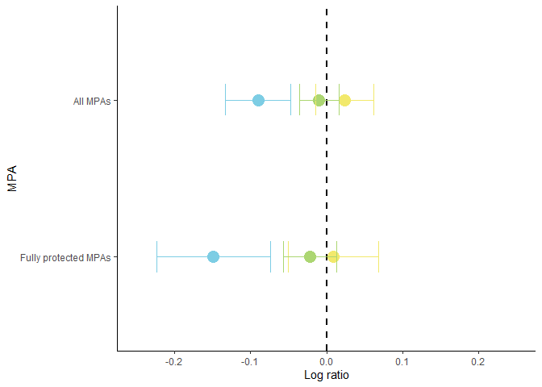

```r
plot_metafor_summary <-ggplot(data = d_summary,aes(x=Est,y=fct_reorder(pair,Est),color = Index))+
  geom_vline(xintercept = 0,linetype = "dashed",size = 1)+
  geom_point(size = 5)+
  geom_point(data = o_summary,aes(x=Est,y= pair,color=Index),size = 5)+
  geom_point(data = t_summary,aes(x=Est,y= pair,color=Index),size = 5)+
  theme_classic()+
  ylab("MPA")+
  xlab("Log ratio")+xlim(-0.25,0.25)+
  geom_errorbar(data = d_summary,aes(xmin= Est-SE, xmax=Est+SE), width=.2)+
  geom_errorbar(data = o_summary ,aes(xmin= Est-SE, xmax=Est+SE), width=.2)+
  geom_errorbar(data = t_summary ,aes(xmin= Est-SE, xmax=Est+SE), width=.2)+
  scale_color_manual(values=c('#7DCDE4',"#F2E96C","#ACD672"))+
  theme(legend.position = 'none')

plot_metafor_summary
```

### Save p-values tables

have one table with all p-values of the metafor models

```r
all_model_summary<-rbind(d_summary,o_summary,t_summary)

kable(all_model_summary)
```

| pair | Index | SE | Est | p_val |
| --- | --- | --- | --- | --- |
| All MPAs | Dark diversity | 0.0429827 | -0.0897349 | 0.0368253 |
| Fully protected MPAs | Dark diversity | 0.0745863 | -0.1484578 | 0.0465452 |
| All MPAs | Observed richness | 0.0381641 | 0.0239557 | 0.5301991 |
| Fully protected MPAs | Observed richness | 0.0596689 | 0.0090416 | 0.8795577 |
| All MPAs | Species pool | 0.0258271 | -0.0096664 | 0.7082017 |
| Fully protected MPAs | Species pool | 0.0350844 | -0.0218588 | 0.5332608 |

# Pair-wise analyses

analyses for the 3 case studies

```r
labl<-c(dark = "Dark diversity",
        observed_richness = "Observed richness",
        total="Species pool")

dd_data$protection<-ifelse(dd_data$protection=="Protected","MPA","Control")
```

## Banyuls

```r
# filter Banyuls site

Banyuls <- dd_data %>% filter(Site == "Banyuls")

# conduct t.tests for the each diversity component

d<-t.test(dark ~ protection, data = Banyuls) # dark diversity
o<-t.test(observed_richness ~ protection, data = Banyuls) #observed richness
t<-t.test(total ~ protection, data = Banyuls) # species pool

# get p-values

pval<-data.frame(index = c("dark","observed_richness","total"),
                 p_val = c(d[["p.value"]],o[["p.value"]],t[["p.value"]]))

# add significant signs

pval<- pval %>% mutate(sign = case_when(p_val > 0.1 ~ "",
                                        p_val > 0.05 & p_val <= 0.1 ~ "",
                                        p_val > 0.01 & p_val <= 0.05 ~ "*",
                                        p_val > 0.001 & p_val <= 0.01 ~ "**",
                                        p_val <= 0.001 ~ "***"))

# calculate means and se

Banyuls<-gather(Banyuls,"index","richness",22:24)

Banyuls <- Banyuls %>% group_by(Site,protection,enforcement,index) %>% summarise("mean_richness" = mean(richness),"se" = std.error(richness), "sd" = sd(richness))
```

```
## can override using the `.groups` argument.
```

```r
# unite with significant sings

Banyuls<-left_join(Banyuls,pval)
```

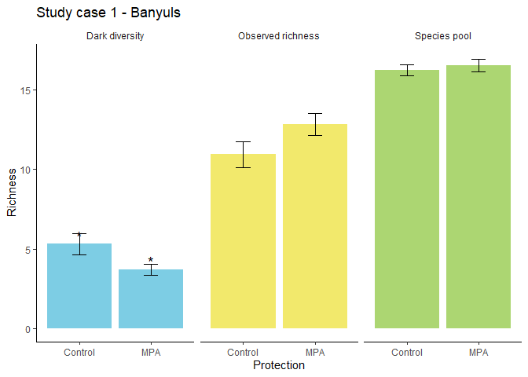

```r
# plot

Plot_banyuls <-ggplot(data = Banyuls, aes(x = protection,
                           y = mean_richness,
                           fill = index)) +
  geom_bar(position = "dodge", stat = "identity")+
   geom_errorbar(aes(ymin=mean_richness-se, ymax=mean_richness+se), width=.2,
                 position=position_dodge(.9)) +
 geom_text(data = Banyuls,
            aes(x = protection,y = mean_richness + 0.5, label = sign),
            size = 5)+
  facet_grid( ~ index,labeller = as_labeller(labl))+
  theme_classic()+
  scale_fill_manual(values=c('#7DCDE4','#F2E96C',"#ACD672"))+
  ggtitle("Study case 1 - Banyuls")+
  ylab("Richness")+xlab("Protection")+
  theme(legend.position = "none",
        strip.background = element_blank())

Plot_banyuls
```

```r
rm(d,o,t,pval)
```

## Medes

```r
# filter Banyuls site

Medes <- dd_data %>% filter(Site %in% c("medes","montgri"))

Medes$Site<-"medes"

# conduct t.tests for the each diversity component

d<-t.test(dark ~ protection, data = Medes) # dark diversity
o<-t.test(observed_richness ~ protection, data = Medes) #observed richness
t<-t.test(total ~ protection, data = Medes) # species pool

# get p-values

pval<-data.frame(index = c("dark","observed_richness","total"),
                 p_val = c(d[["p.value"]],o[["p.value"]],t[["p.value"]]))

# add significant signs

pval<- pval %>% mutate(sign = case_when(p_val > 0.1 ~ "",
                                        p_val > 0.05 & p_val <= 0.1 ~ "",
                                        p_val > 0.01 & p_val <= 0.05 ~ "*",
                                        p_val > 0.001 & p_val <= 0.01 ~ "**",
                                        p_val <= 0.001 ~ "***"))

# calculate means and se

Medes<-gather(Medes,"index","richness",22:24)

Medes <- Medes %>% group_by(Site,protection,enforcement,index) %>% summarise("mean_richness" = mean(richness),"se" = std.error(richness), "sd" = sd(richness))
```

```
## can override using the `.groups` argument.
```

```r
# unite with significant sings

Medes<-left_join(Medes,pval)
```

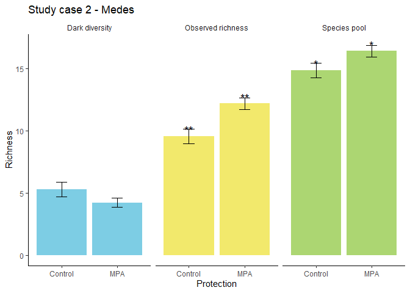

```r
# plot

Plot_medes <-ggplot(data = Medes, aes(x = protection,
                           y = mean_richness,
                           fill = index)) +
  geom_bar(position = "dodge", stat = "identity")+
   geom_errorbar(aes(ymin=mean_richness-se, ymax=mean_richness+se), width=.2,
                 position=position_dodge(.9)) +
 geom_text(data = Medes,
            aes(x = protection,y = mean_richness + 0.5, label = sign),
            size = 5)+
  facet_grid( ~ index,labeller = as_labeller(labl))+
  theme_classic()+
  scale_fill_manual(values=c('#7DCDE4','#F2E96C',"#ACD672"))+
  ggtitle("Study case 2 - Medes")+
  ylab("Richness")+xlab("Protection")+
  theme(legend.position = "none",
        strip.background = element_blank())

Plot_medes
```

```r
rm(d,o,t,pval)
```

## Brijoni

```r
Brijoni <- dd_data %>% filter(Site == "brijuni")

# conduct t.tests for the each diversity component

d<-t.test(dark ~ protection, data = Brijoni) # dark diversity
o<-t.test(observed_richness ~ protection, data = Brijoni) #observed richness
t<-t.test(total ~ protection, data = Brijoni) # species pool

# get p-values

pval<-data.frame(index = c("dark","observed_richness","total"),
                 p_val = c(d[["p.value"]],o[["p.value"]],t[["p.value"]]))

# add significant signs

pval<- pval %>% mutate(sign = case_when(p_val > 0.1 ~ "",
                                        p_val > 0.05 & p_val <= 0.1 ~ "",
                                        p_val > 0.01 & p_val <= 0.05 ~ "*",
                                        p_val > 0.001 & p_val <= 0.01 ~ "**",
                                        p_val <= 0.001 ~ "***"))

# calculate means and se

Brijoni<-gather(Brijoni,"index","richness",22:24)

Brijoni <- Brijoni %>% group_by(Site,protection,enforcement,index) %>% summarise("mean_richness" = mean(richness),"se" = std.error(richness), "sd" = sd(richness))
```

```
## can override using the `.groups` argument.
```

```r
# unite with significant sings

Brijoni<-left_join(Brijoni,pval)
```

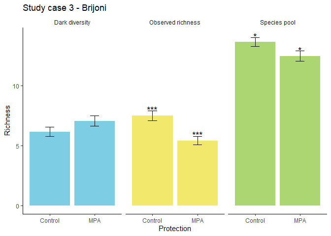

```r
# plot

Plot_brijoni <-ggplot(data = Brijoni, aes(x = protection,
                           y = mean_richness,
                           fill = index)) +
  geom_bar(position = "dodge", stat = "identity")+
   geom_errorbar(aes(ymin=mean_richness-se, ymax=mean_richness+se), width=.2,
                 position=position_dodge(.9)) +
 geom_text(data = Brijoni,
            aes(x = protection,y = mean_richness + 0.5, label = sign),
            size = 5)+
  facet_grid( ~ index,labeller = as_labeller(labl))+
  theme_classic()+
  scale_fill_manual(values=c('#7DCDE4','#F2E96C',"#ACD672"))+
  ggtitle("Study case 3 - Brijoni")+
  ylab("Richness")+xlab("Protection")+
  theme(legend.position = "none",
        strip.background = element_blank())

Plot_brijoni
```

```r
rm(d,o,t,pval)
```

# Plot figure 4

later I will unite to one plot

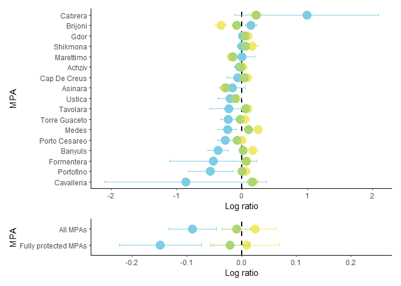

```r
fig_4_left <- plot_log_ratio / plot_metafor_summary +
  plot_layout( heights  = c(15,3))

fig_4_left
```

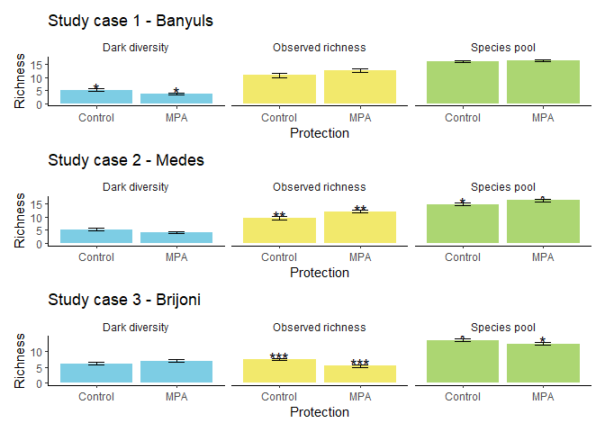

```r
#ggsave("fig_4_left.pdf",fig_4_left,path = dir, width = 5, height = 10)

fig_4_right <- Plot_banyuls/Plot_medes/Plot_brijoni
fig_4_right
```

```r
#ggsave("fig_4_right.pdf",fig_4_right,path = dir, width = 5, height = 10)
```

# Completness

Organize the data and calculate the mean completeness.

count how many transects with `INF` there is in the data

```r
nrow(log_data %>%
  filter(index == "completeness") %>%
  filter(richness == Inf))
```

```
## [1] 194
```

Remove transect where dark diversity = 0 and thus completeness = Infinity

```r
completness <-log_data %>%
  filter(index == "completeness") %>%
  filter(richness != Inf) %>%
  group_by(pair,protection) %>%
  summarise(mean = mean(richness),
            sd = sd(richness),
            n = n())
completness<-completness%>% pivot_wider(names_from=protection,
              values_from=c(mean,
                            sd,
                            n))

completness<-completness %>% mutate(diffrance = mean_MPA - mean_Control)
```

Calculate the effect size based on the `Mean Difference` index

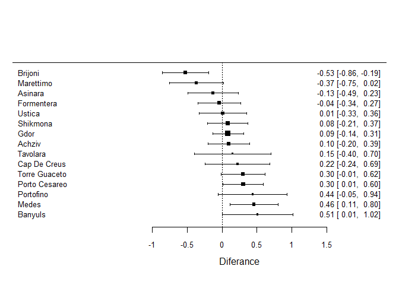

```r
effect_sizes_comp <- escalc(
    "MD",
    m1i = mean_MPA,
    n1i = n_MPA,
    sd1i = sd_MPA,
    m2i = mean_Control,
    n2i = n_Control,
    sd2i = sd_Control,
    var.names=c("yi","vi"),
    data = completness)


# Plot the forest plot (just to make sure everything is ok)

forest(
  effect_sizes_comp$yi, # These are effect sizes from each row in database
  effect_sizes_comp$vi, # These are variances from each row in database
  annotate = T,            # Setting this to false prevents R from including CIs for each effect sizes
  order="obs",             # set the order of the sites
  slab = effect_sizes_comp$pair, # A individual effect size labeled
  xlab = "Diferance", # Label for x-axis
  cex = .8,                    # Text side for study labels
  pch = 15,                    # shape of bars in forest plot
  cex.lab = 1                  # Size of x-axis label
)
```

### Plot log-ratio - completness

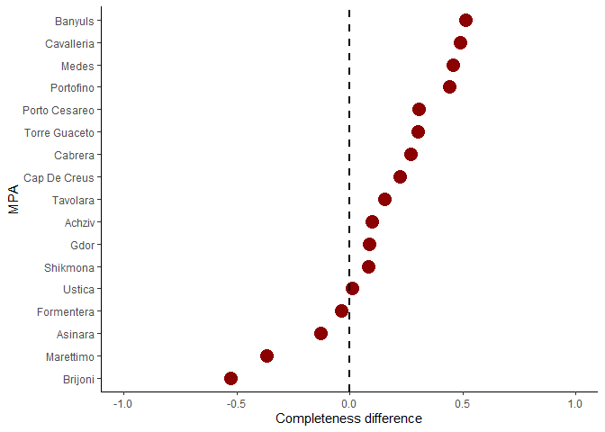

```r
plot_log_ratio_comp<-ggplot(
  effect_sizes_comp,aes(x=yi,y=fct_reorder(pair,yi)))+
  geom_point(size =5,color = "darkred")+
  geom_vline(xintercept = 0,linetype = "dashed",size = 1)+
  ylab("MPA")+
  xlab("Completeness difference")+ xlim(c(-1,1))+
  theme_classic()+theme(legend.position = 'none')

plot_log_ratio_comp
```

## Metafor - completeness

run metafor model

```r
# All MPAs

comp_model<- rma(yi,
                  vi,
                  method = "REML",
                  slab = pair,
                  data = effect_sizes_comp)
comp_model
```

```
##
## Random-Effects Model (k = 15; tau^2 estimator: REML)
##
## tau^2 (estimated amount of total heterogeneity): 0.0464 (SE = 0.0298)
## tau (square root of estimated tau^2 value):      0.2155
## I^2 (total heterogeneity / total variability):   60.72%
## H^2 (total variability / sampling variability):  2.55
##
## Test for Heterogeneity:
## Q(df = 14) = 33.9567, p-val = 0.0021
##
## Model Results:
##
## estimate      se    zval    pval    ci.lb   ci.ub
##   0.0922  0.0730  1.2627  0.2067  -0.0509  0.2354
##
## ---
## Signif. codes:  0 '***' 0.001 '**' 0.01 '*' 0.05 '.' 0.1 ' ' 1
```

```r
#Fully protected MPAs


completness_pro <-log_data %>%
  filter(index == "completeness") %>%
  filter(richness != Inf) %>%
  filter(!(pair == "Asinara" & enforcement == 2)) %>%
  filter(pair %in% fully_protected_pairs$pair) %>%
  group_by(pair,protection) %>%
  summarise(mean = mean(richness),
            sd = sd(richness),
            n = n())
completness_pro <-completness_pro%>% pivot_wider(names_from=protection,
              values_from=c(mean,
                            sd,
                            n))

completness_pro<-completness_pro %>% mutate(diffrance = mean_MPA - mean_Control)



effect_sizes_comp_pro <- escalc(
    "MD",
    m1i = mean_MPA,
    n1i = n_MPA,
    sd1i = sd_MPA,
    m2i = mean_Control,
    n2i = n_Control,
    sd2i = sd_Control,
    var.names=c("yi","vi"),
    data = completness_pro)



effect_sizes_comp_pro <-effect_sizes_comp_pro %>% filter(pair %in% fully_protected_pairs$pair)


pro_comp_model <- rma(yi,
                       vi,
                       method = "REML",
                       slab = pair,
                       data = effect_sizes_comp_pro)

pro_comp_model
```

```
##
## Random-Effects Model (k = 9; tau^2 estimator: REML)
##
## tau^2 (estimated amount of total heterogeneity): 0.0779 (SE = 0.0581)
## tau (square root of estimated tau^2 value):      0.2792
## I^2 (total heterogeneity / total variability):   68.89%
## H^2 (total variability / sampling variability):  3.21
##
## Test for Heterogeneity:
## Q(df = 8) = 25.5971, p-val = 0.0012
##
## Model Results:
##
## estimate      se    zval    pval    ci.lb   ci.ub
##   0.1232  0.1140  1.0801  0.2801  -0.1003  0.3467
##
## ---
## Signif. codes:  0 '***' 0.001 '**' 0.01 '*' 0.05 '.' 0.1 ' ' 1
```

insert model info into table for plotting

```r
c_summary<-data.frame(a=1)

c_summary$pair <- "All MPAs"

c_summary$ci_l<-comp_model$ci.lb
c_summary$ci_u<-comp_model$ci.ub
c_summary$Est<-comp_model$b[[1]]
c_summary$p_val<-comp_model[["pval"]]
c_summary$a<-NULL


c_summary_pro<-data.frame(a=1)

c_summary_pro$pair <- "Fully protected MPAs"

c_summary_pro$ci_l<-pro_comp_model$ci.lb
c_summary_pro$ci_u<-pro_comp_model$ci.ub
c_summary_pro$Est<-pro_comp_model$b[[1]]
c_summary_pro$p_val<-pro_comp_model[["pval"]]
c_summary_pro$a<-NULL

c_summary<-rbind(c_summary,c_summary_pro)

rm(c_summary_pro)

c_summary$pair<-as.factor(c_summary$pair)
```

## Metafor completeness plots

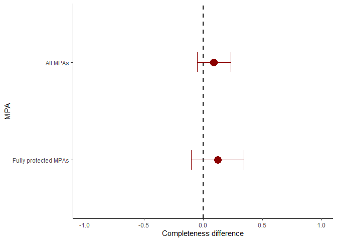

```r
plot_metafor_comp <- ggplot(data = c_summary, aes(x = Est, y = factor(pair, levels = rev(levels(pair))))) +
  geom_vline(xintercept = 0, linetype = "dashed", size = 1) +
  geom_point(size = 5, color = "darkred") +
  theme_classic() +
  ylab("MPA") +
  xlab("Completeness difference") + xlim(-1, 1) +
  geom_errorbar(data = c_summary, aes(xmin = ci_l, xmax = ci_u), width = 0.2, color = "darkred") +
  theme(legend.position = 'none')

plot_metafor_comp
```

# PLot completeness appendix

combine log-ratio with metafor model results

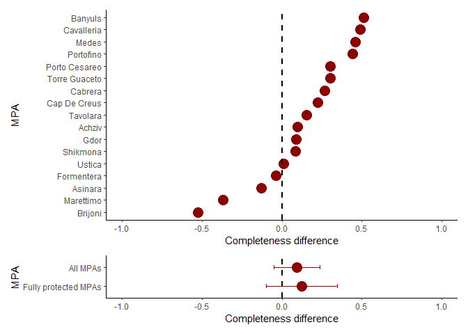

```r
Completeness_effect_size <- plot_log_ratio_comp / plot_metafor_comp +
  plot_layout( heights  = c(15,3))

Completeness_effect_size
```

```r
#ggsave("Completeness_effect_size.pdf",path = dir,width = 5,height = 10)
```